# ADPS 2025Z — Laboratorium 1 (rozwiązania)

# Zadanie 1 (1 pkt)

## Treść zadania

Dla danych z ostatnich 18 miesięcy dotyczących wybranych dwóch spółek giełdowych:

- sporządź wykresy procentowych zmian kursów zamknięcia w zależności od daty,
- wykreśl i porównaj histogramy procentowych zmian kursów zamknięcia,
- wykonaj jeden wspólny rysunek z wykresami pudełkowymi zmian kursów zamknięcia.

## Rozwiązanie

```
# https://stooq.pl/q/d/l/?s=kgh&i=d
Ticket_KGH = 'KGH'
webLink = paste0('https://stooq.pl/q/d/l/?s=', Ticket_KGH, '&i=d')
fileName = paste0(Ticket_KGH, '.csv')
if(!file.exists(fileName)) {
download.file(webLink, fileName)
}
df_KGH = read.csv('KGH.csv')
df_KGH$Data = as.Date(df_KGH$Data)
df_KGH$Zamkniecie_zm = with(df_KGH, c(NA, 100*diff(Zamkniecie)/Zamkniecie[-length(Zamkniecie)]))
df_KGH_18m = df_KGH[which(df_KGH$Data >= '2024-04-19' & df_KGH$Data <= Sys.Date()),]
plot(Zamkniecie_zm ~ Data, df_KGH_18m, type = 'l', col = 'green', xlab = 'Data',
ylab = 'Procentowa zmiana kursu zamknięcia [%]', main = 'KGHM')
grid()
```

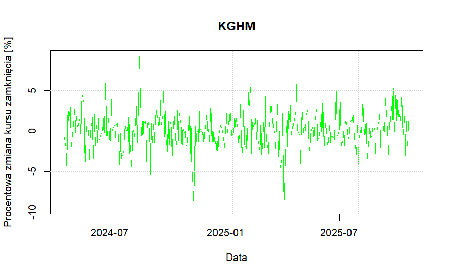

```
# https://stooq.pl/q/d/l/?s=kgh&i=d
Ticket_PKO = 'PKO'
webLink = paste0('https://stooq.pl/q/d/l/?s=', Ticket_PKO, '&i=d')
fileName = paste0(Ticket_PKO, '.csv')
if(!file.exists(fileName)) {
download.file(webLink, fileName)
}
df_PKO = read.csv('PKO.csv')
df_PKO$Data = as.Date(df_PKO$Data)
df_PKO$Zamkniecie_zm = with(df_PKO, c(NA, 100*diff(Zamkniecie)/Zamkniecie[-length(Zamkniecie)]))
df_PKO_18m = df_PKO[which(df_PKO$Data >= '2024-04-19' & df_PKO$Data <= Sys.Date()),]
plot(Zamkniecie_zm ~ Data, df_PKO_18m, type = 'l', col = 'blue', xlab = 'Data',
ylab = 'Procentowa zmiana kursu zamknięcia [%]', main = 'PKO')
grid()
```

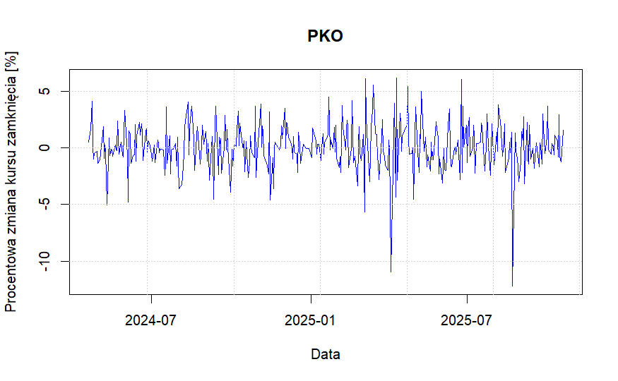

```
hist(df_KGH_18m$Zamkniecie_zm, breaks = 50, prob = T,
xlab = 'Zmiana kursu zamknięcia [%] ',
ylab = 'Częstość występowania',
main = paste('Histogram procentowych zmian kursu', 'KGHM') )
grid()
```

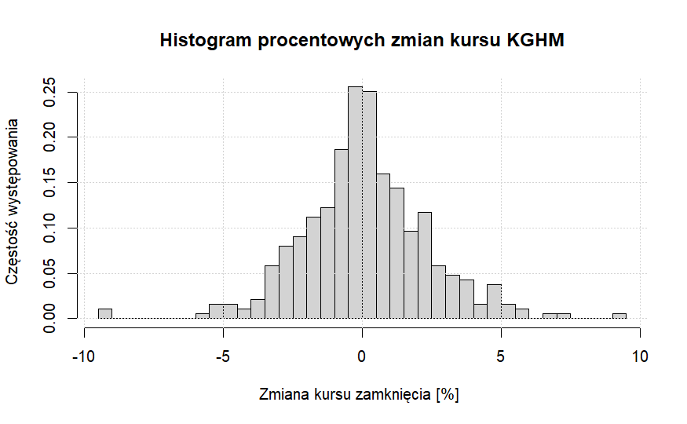

```
hist(df_PKO_18m$Zamkniecie_zm, breaks = 50, prob = T,
xlab = 'Zmiana kursu zamknięcia [%] ',
ylab = 'Częstość występowania',
main = paste('Histogram procentowych zmian kursu', 'PKO') )
grid()
```

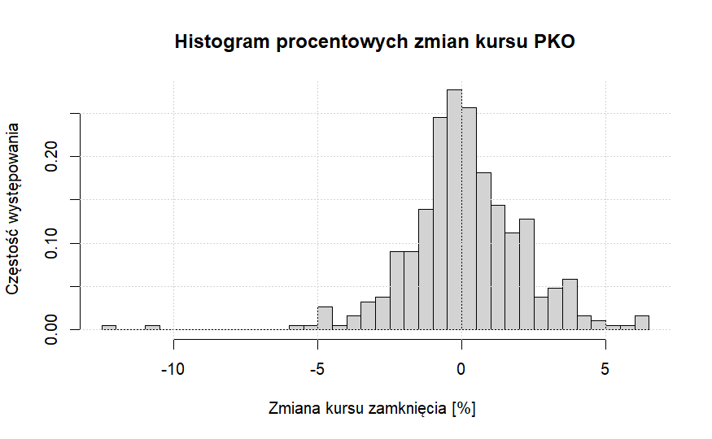

```
boxplot(df_KGH_18m$Zamkniecie_zm,
        df_PKO_18m$Zamkniecie_zm,
        names = c("KGHM", "PKO"),
        col = c("green", "blue"),
        ylab = "Zmiana kursu zamknięcia [%]",
        main = "Porównanie zmian kursu zamknięcia")
grid()
```

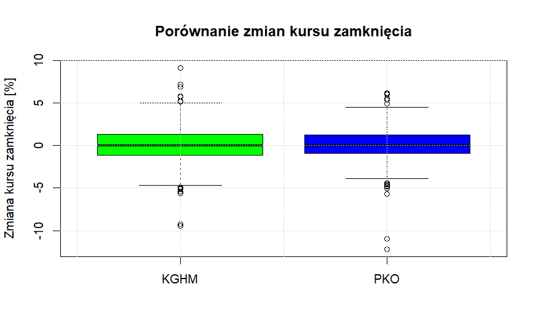

# Zadanie 2 (1,5 pkt)

## Treść zadania

1. Sporządź wykres liczby katastrof lotniczych w poszczególnych:
- miesiącach roku (styczeń - grudzień),

```
kat = read.csv('crashes.csv')
# Dodanie do danych kolumny z miesiącem:
kat$Month = strftime(as.Date(kat$Date, '%m/%d/%Y'), '%m')
# Wykres liczby wypadków w poszczególnych miesiącach:
plot(table(kat$Month), type = 'h', col = 'blue', xlab = 'Miesiąc',
ylab = 'Liczba katastrof', main = 'Liczba katastrof w poszczególnych miesiącach' )
grid()
```

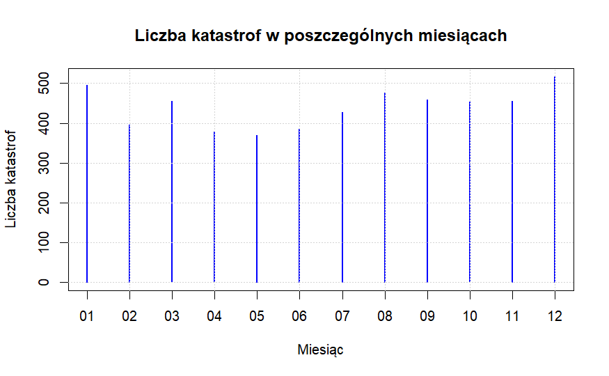

- dniach miesiąca (1-31),

```
# Dodanie do danych kolumny z dniem:
kat$Day = strftime(as.Date(kat$Date, '%m/%d/%Y'), '%d')
# Wykres liczby wypadków w danym dniu miesiąca:
plot(table(kat$Day), type = 'h', col = 'blue', xlab = 'Dzień miesiąca',
ylab = 'Liczba katastrof', main = 'Liczba katastrof w poszczególnych dniach miesiąca' )
grid()
```

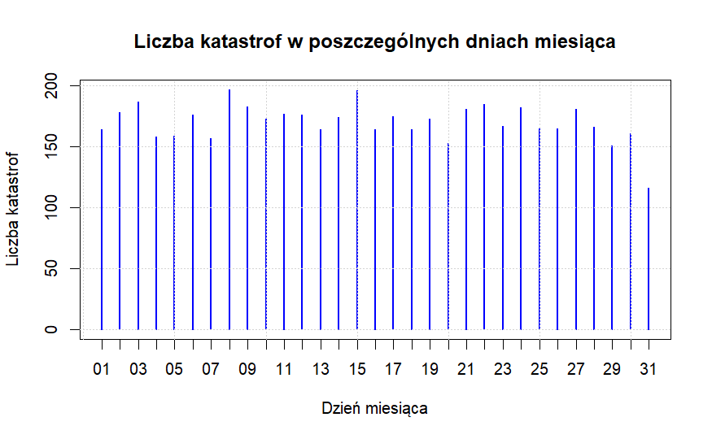

- dniach tygodnia (weekdays()).

```
try(Sys.setlocale("LC_TIME", "pl_PL.UTF-8"), silent = TRUE)
```

```
[1] "pl_PL.UTF-8"
```

```
# Dodanie do danych kolumny z dniem tygodnia:
kat$Weekday = weekdays(as.Date(kat$Date, '%m/%d/%Y'), abbreviate = TRUE)
#unique(kat$Weekday)

# Wykres liczby wypadków w danym dniu miesiąca:
plot(table(kat$Weekday), type = 'h', col = 'blue', xlab = 'Dzień tygodnia',
ylab = 'Liczba katastrof', main = 'Liczba katastrof w poszczególnych dniach tygodnia' )
grid()
```

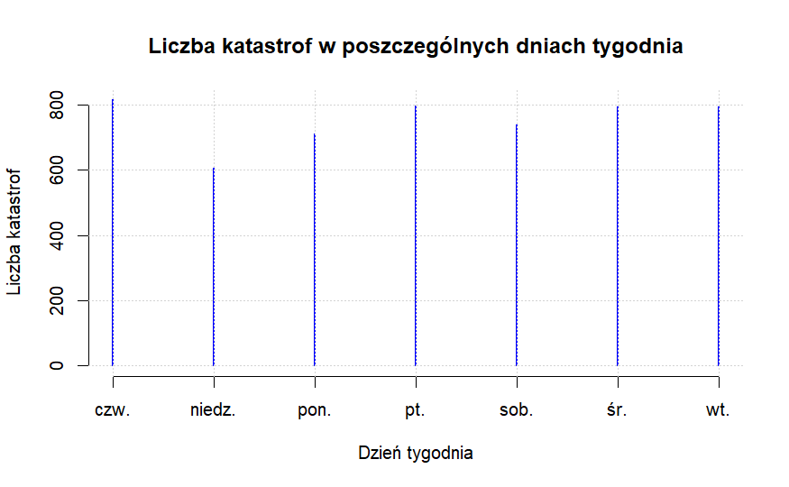

```
try(Sys.setlocale("LC_TIME", "pl_PL.UTF-8"), silent = TRUE)
```

```
[1] "pl_PL.UTF-8"
```

```
# Dodanie do danych kolumny z dniem tygodnia:
kat$Weekday <- weekdays(as.Date(kat$Date, '%m/%d/%Y'), abbreviate = TRUE)

# Ustawienie właściwej kolejności dni tygodnia (zgodnie z Twoimi nazwami)
kat$Weekday <- factor(kat$Weekday,
                      levels = c("pon.", "wt.", "śr.", "czw.", "pt.", "sob.", "niedz."))

# Wykres liczby wypadków w danym dniu tygodnia:
plot(table(kat$Weekday),
     type = 'h',
     col = 'blue',
     xlab = 'Dzień tygodnia',
     ylab = 'Liczba katastrof',
     main = 'Liczba katastrof w poszczególnych dniach tygodnia')
grid()
```

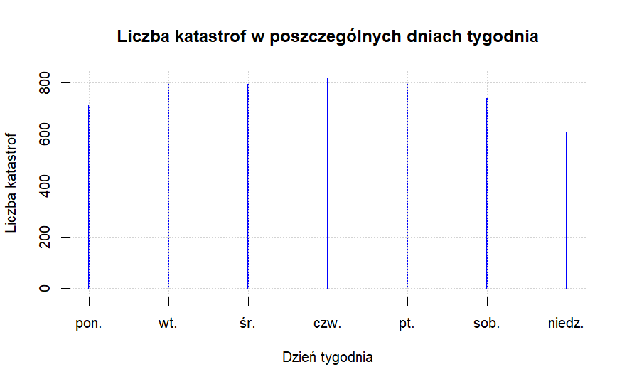

2. Narysuj jak w kolejnych latach zmieniały się:
- liczba osób, które przeżyły katastrofy,

```
kat$Year = strftime(as.Date(kat$Date, '%m/%d/%Y'), '%Y')
# Agregacja danych po latach:
Ocaleni = aggregate((Aboard - Fatalities) ~ Year, kat, FUN = sum)

# Wykres:
plot(Ocaleni, type = 'h', col = 'blue',xlab = 'Rok',
ylab = 'Lczba ocalałych', main = 'Liczba osób, które przeżyły katastrofy' )
grid()
```

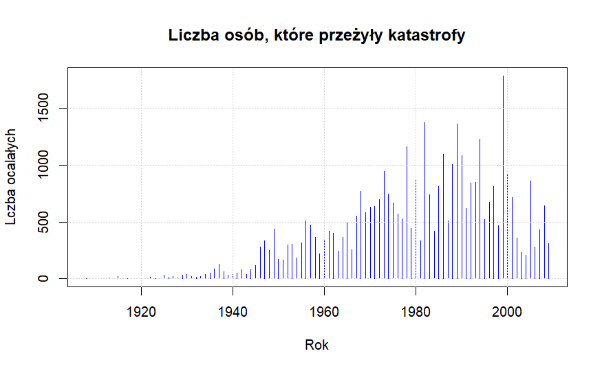

```
# kat$Year = strftime(as.Date(kat$Date, '%m/%d/%Y'), '%Y')
# Agregacja danych po latach:
Odsetek_ocalałych = aggregate((((Aboard - Fatalities)/Aboard)*100) ~ Year, kat, FUN = sum)
# Wykres:
plot(Odsetek_ocalałych, type = 'h', col = 'blue',xlab = 'Rok',
ylab = 'Odsetek ocalałych', main = 'Odsetek osób, które przeżyły katastrofy' )
grid()
```

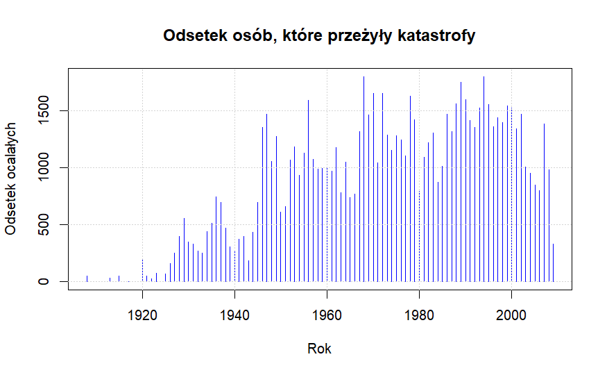

## Rozwiązanie

# Zadanie 3 (1 pkt)

## Treść zadania

1. Dla dwóch różnych zestawów parametrów rozkładu dwumianowego (rbinom):
- Binom(20,0.2)
- Binom(20,0.8)

wygeneruj próby losowe składające się z M = 1000 próbek i narysuj wartości wygenerowanych danych.

2. Dla każdego z rozkładów narysuj na jednym rysunku empiryczne i teoretyczne (użyj funkcji dbinom) funkcje prawdopodobieństwa, a na drugim rysunku empiryczne i teoretyczne (użyj funkcji pbinom) dystrybuanty. W obu przypadkach wyskaluj oś odciętych od 0 do 20.

# Zadanie 4 (1,5 pkt)

## Treść zadania

1. Dla rozkładu dwumianowego Binom(20, 0.2) wygeneruj trzy próby losowe składające się z M = 100, 1000 i 10000 próbek.
2. Dla poszczególnych prób wykreśl empiryczne i teoretyczne funkcje prawdopodobieństwa, a także empiryczne i teoretyczne dystrybuanty.
3. We wszystkich przypadkach oblicz empiryczne wartości średnie i wariancje. Porównaj je ze sobą oraz z wartościami teoretycznymi dla rozkładu Binom(20, 0.2).